## OVERVIEW

We pursue our series of blog articles illustrating rjags programs for diagnostic meta-analysis with an article describing how to carry out Bayesian inference for the Hierarchical Summary Receiver Operating Characteristic (HSROC) meta-analysis model (Rutter and Gatsonis(2001), Chu, Chen and Louis(2009)) when a perfect reference test is available. (For our previous article on the Bayesian bivariate model for diagnostic meta-analysis click [here](https://nandinidendukuri.com/bayesian-inference-for-the-bivariate-model-for-diagnostic-meta-analysis/))

Through this blog, we will look at each step of a program in the R language (R Core Team(2020)). The program uses the rjags package (an interface to the JAGS library (Plummer(2003))) in order to draw samples from the posterior distribution of the parameters using Markov Chain Monte Carlo (MCMC) methods. The program relies on the mcmcplots package to assess convergence of the meta-analysis model. The meta-analtsis model returns the parameters of the SROC curve across studies. The SROC curve can be created using the DTAplots package.

## MOTIVATING EXAMPLE AND DATA

|  | Disease_positive | Disease_negative |
| --- | --- | --- |
| Inex test positive | TP | FP |
| Index test negative | FN | TN |

where:

- `TP` is the number of individuals who tested positive on both tests
- `FP` is the number of individuals who tested positive on the index test and negative on the reference test
- `FN` is the number of individuals who tested negative on the index test and positive on the reference test
- `TN` is the number of individuals who tested negative on both tests

```r
TP=c(64, 482, 36, 143, 80, 61, 27, 60, 261, 20, 42, 18, 8, 93, 143,
     84, 30, 32, 70, 48, 75, 64, 32, 130, 50, 20, 77, 73, 36, 56,
     115, 49, 22, 8, 35, 161, 80, 5, 57, 383, 89, 57, 196, 163, 75,
     157, 26, 62, 113, 25)
FP=c(16, 2, 6, 43, 50, 36, 6, 8, 54, 2, 46, 3, 8, 28, 39, 41, 2,
     29, 39, 1, 42, 18, 10, 8, 14, 32, 16, 22, 3, 11, 53, 23, 2, 8,
     8, 89, 28, 4, 9, 38, 3, 25, 75, 10, 21, 287, 1, 11, 19, 1)
FN=c(27, 82, 41, 53, 39, 37, 3, 20, 63, 29, 14, 31, 0, 25, 63, 56,
     23, 3, 36, 40, 12, 29, 9, 128, 20, 26, 52, 29, 5, 46, 67, 28,
     20, 31, 51, 7, 69, 11, 33, 166, 9, 6, 99, 28, 21, 78, 32, 114,
     29, 14)
TN=c(153, 153, 313, 196, 45, 196, 33, 119, 197, 18, 127, 25, 31,
     118, 130, 90, 73, 13, 93, 99, 191, 73, 13, 113, 191, 25, 52,
     90, 70, 87, 63, 359, 80, 91, 149, 360, 284, 49, 93, 170, 39,
     111, 345, 140, 106, 1466, 29, 127, 481, 20)

pos= TP + FN
neg= TN + FP

n <- length(TP) #  Number of studies

dataList = list(TP=TP,TN=TN,n=n,pos=pos,neg=neg)
```

## THE MODEL

Before moving any further, let’s look briefly at the theory behind the hierarchical meta-analysis model. An HSROC model assumes that there is an underlying ROC curve in each study behind the observed data.

**Within-study level:** In each study, the `TP` and `TN` entries of the 2x2 table are assumed to follow a binomial distribution with probabilities expressed as follows :

$$logit(se_i) = \left(\theta_i + \frac{\alpha_i}{2} \right)e^{-\frac{\beta}{2}} \\
logit(sp_i) = \left(-\theta_i + \frac{\alpha_i}{2} \right)e^{\frac{\beta}{2}}$$

where $se_i$ and $sp_i$ are the sensitivity and specificity in study $i$ respectively, $\theta_i$ represents the positivity threshold in study $i$, $\alpha_i$ represents a measure of diagnsotic accuracy in the $i^{th}$ study and $\beta$ (the shape parameter) provides for asymmetry in the ROC curve by allowing accuracy to vary with threshold. It is assumed that $\beta$ is the same in each study.

**Between-study level:** For each study, both $\theta_i$ and $\alpha_i$ are assumed to follow a normal distribution:

$$\theta_i \sim N(\Theta, \sigma^2_{\theta}) \\
\alpha_i \sim N(\Lambda, \sigma^2_{\alpha})$$
where $\Theta$ is the average positivity threshold, $\Lambda$ is the mean accuracy, $\sigma^2_{\theta}$ and $\sigma^2_{\alpha}$ are the variance of the positivity threshold and accuracy respectively.

To carry out Bayesian estimation, we need to specify prior distributions over the unknown parameters, namely, for $\Theta$, $\Lambda$, $\beta$, $\sigma^2_{\theta}$ and $\sigma^2_{\alpha}$.

The model is written in JAGS syntax, and stored in a character object that we called `modelString`. It is later saved in the current working directory via the R function `writeLines` as follows.

```r
# Bayesian HSROC model
modelString =
"
model {
# === LIKELIHOOD === #
for(i in 1:n) {
TP[i] ~ dbin(se[i],pos[i])
TN[i] ~ dbin(sp[i],neg[i])
# === HIERARCHICAL PRIOR === #
logit(se[i]) <- (theta[i] + 0.5*alpha[i])/exp(beta/2)
logit(sp[i]) <- (-theta[i] + 0.5*alpha[i])*exp(beta/2)
theta[i] ~ dnorm(THETA,prec[2])
alpha[i] ~ dnorm(LAMBDA,prec[1])
}
### === HYPER PRIOR DISTRIBUTIONS === ###
THETA ~ dunif(-10,10)
LAMBDA ~ dunif(-2,20)
beta ~ dunif(-5,5)
for(i in 1:2) {
prec[i] ~ dgamma(2.1,2)
tau.sq[i] <- 1/prec[i]
tau[i] <- pow(tau.sq[i],0.5)
}
}
"

writeLines(modelString,con="model.txt")
```

## INTIAL VALUES

To assess convergence of the MCMC algorithm, we recommend running multiple chains, each starting at different initial values in order to examine if all chains reach the same solution. There are different ways of providing initial values. In the illustration below we give details on how to provide initial values chosen by the user by using a function we created and called `GenInits()`.

Providing relevant initial values can speed up convergence of the MCMC algorithm. The function we created allows us to provide our own initial values for the average positivity threshold (`THETA`), the mean accuracy (`LAMBDA`) as well as the shape parameter (`beta`). By setting the chain argument in `GenInits()` equal to `myinits` we can provide specific initial values to `THETA`, `LAMBDA` and `beta` through the `THETA`, `LAMBDA` and `beta` arguments respectively or we can use the function to randomly generate initial values from distributions of our choice for `THETA`, `LAMBDA` and `beta`. In this example, we have allowed other parameters, such as precision parameters (`prec[1]` and `prec[2]`) to be randomly generated by `GenInits()`. In our experience, choosing initial values for these parameters is not easy. For reproducibility, a Seed argument is provided.

In the illustration below, for all chains we simply set the argument `chain` to 1, 2, 3, 4 and 5, respectively. This ensure the chains are randomly initialized.

```r
# Initial values
GenInits = function(chain, Seed=seed, THETA=NULL, LAMBDA=NULL, beta=NULL){
        if(chain == "myinits"){
                THETA=THETA;
                LAMBDA=LAMBDA;
                beta=beta;
        }
        else{
                THETA = runif(1, -10, 10);
                LAMBDA = runif(1, -2, 20);
                beta = runif(1, -5, 5) ;
        }
        list(
                THETA = THETA,
                LAMBDA = LAMBDA,
                beta = beta,
                prec = rep(rgamma(1,shape=2.1,rate=2), 2),
                .RNG.name="base::Wichmann-Hill",
                .RNG.seed=Seed
        )
}
seed=8; set.seed(seed)
Listinits = list(
        GenInits(chain=1),
        GenInits(chain=2),
        GenInits(chain=3),
        GenInits(chain=4),
        GenInits(chain=5)
)
```

## COMPILING AND RUNNING THE MODEL

The `jags.model` function compiles the model to check for possible syntax error. Argument `n.chains=5` creates 5 MCMC chains with different starting values given by the `Listinits` object defined above. At this step, `jags.model` is said to be in adaptive mode in order to ensure optimal sampling behaviour in the later steps. By default, it will run and discard 1,000 iterations. This value can be tweaked with the `n.adapt` argument. (See [Section 3.4](https://people.stat.sc.edu/hansont/stat740/jags_user_manual.pdf) of the JAGS manual for further details.)

```r
library(rjags)
# Compile the model
jagsModel = jags.model("model.txt",data=dataList,n.chains=5,inits=Listinits)
```

The `update` function serves as to carry out the “burn-in” step. This corresponds to discarding initial iterations till the MCMC algorithm has reached its equilibrium distribution. Here we chose to discard 5,000 iterations by providing argument `n.iter=5000`. This step can be helpful to mitigate “bad” initial values.

```r
# Burn-in iterations
update(jagsModel,n.iter=5000)
```

The `coda.samples` function draws samples from the posterior distribution of the unknown parameters that were defined in the parameters object. Here we are running `n.iter=15000` iterations in each chain.

```r
# Parameters to be monitored
parameters = c( "se", "sp", "alpha", "theta", "prec", "tau.sq", "tau", "THETA", "LAMBDA", "beta")
# Posterior samples
output = coda.samples(jagsModel,variable.names=parameters,n.iter=15000)
```

## MONITORING CONVERGENCE

Convergence of the MCMC algorithm can now be examined. The code below will create a 3-panel plot consisting of the density plot, the running mean plot and a history plot for parameters that vary across studies, e.g. prevalence, sensitivity and specificity in each study.

```r
library(mcmcplots)
# Plots to check convergence for parameters varying across studies:
# Index j refers to the number of studies
# Index i follows the ordering of the parameters vector defined above.  If left unchanged :
# i = 1 : logit-transformed sensitivity in study j (se)
# i = 2 : logit-transformed specificity in study j (sp)
# i = 3 : accuracy in study j (alpha)
# i = 4 : positivity threshold in study j (theta)

for(j in 1:n) {
        for(i in 1:4) {
                par(oma=c(0,0,3,0), mar=c(2,2,2,2))
                layout(matrix(c(1,2,3,3), 2, 2, byrow = TRUE))
                denplot(output, parms=c(paste(parameters[i],"[",j,"]",sep="")), auto.layout=FALSE, main="(a)", xlab=paste(parameters[i],"",sep=""), ylab="Density")
                rmeanplot(output, parms=c(paste(parameters[i],"[",j,"]",sep="")), auto.layout=FALSE, main="(b)")
                title(xlab="Iteration", ylab="Running mean")
                traplot(output, parms=c(paste(parameters[i],"[",j,"]",sep="")), auto.layout=FALSE, main="(c)")
                title(xlab="Iteration", ylab=paste(parameters[i],"[",j,"]",sep=""))
                mtext(paste("Diagnostics for ", parameters[i],"[",j,"]","",sep=""), side=3, line=1, outer=TRUE, cex=2)

        }
}
```

Then we create the same 3-panel plot for the parameters that are shared across studies.

```r
# Plots to check convergence for parameters shared across studies:
# Index j = 1 refers to accuracy parameter and j = 2 refers to cut-off value for defining a positive test
# Index i follows the ordering of the parameters vector defined above.  If left unchanged :
# i = 5 : precision of the accuracy parameter (j=1) and precision of the positivity threshold parameter (j=2) (prec)
# i = 6 : variance of the accuracy parameter (j=1) and variance of the positivity threshold parameter (j=2) (tau.sq)
# i = 7 : standard deviation of the accuracy parameter (j=1) and standard deviation of the positivity threshold parameter (j=2) (tau)
for(j in 1:2) {
        for(i in 5:7) {
                par(oma=c(0,0,3,0))
                layout(matrix(c(1,2,3,3), 2, 2, byrow = TRUE))
                denplot(output, parms=c(paste(parameters[i],"[",j,"]",sep="")), auto.layout=FALSE, main="(a)", xlab=paste(parameters[i],"",sep=""), ylab="Density")
                rmeanplot(output, parms=c(paste(parameters[i],"[",j,"]",sep="")), auto.layout=FALSE, main="(b)")
                title(xlab="Iteration", ylab="Running mean")
                traplot(output, parms=c(paste(parameters[i],"[",j,"]",sep="")), auto.layout=FALSE, main="(c)")
                title(xlab="Iteration", ylab=paste(parameters[i],"[",j,"]",sep=""))
                mtext(paste("Diagnostics for ", parameters[i],"[",j,"]","",sep=""), side=3, line=1, outer=TRUE, cex=2)
        }
}

# Index j not needed for the following shared parameters
# i = 8 : mean positivity threshold parameter (THETA)
# i = 9 : mean accuracy parameter (LAMBDA)
# i = 10: shape parameter (beta)
for(i in 8:10) {
        par(oma=c(0,0,3,0))
        layout(matrix(c(1,2,3,3), 2, 2, byrow = TRUE))
        denplot(output, parms=c(paste(parameters[i], sep="")), auto.layout=FALSE, main="(a)", xlab=paste(parameters[i],"",sep=""), ylab="Density")
        rmeanplot(output, parms=c(paste(parameters[i], sep="")), auto.layout=FALSE, main="(b)")
        title(xlab="Iteration", ylab="Running mean")
        traplot(output, parms=c(paste(parameters[i], sep="")), auto.layout=FALSE, main="(c)")
        title(xlab="Iteration", ylab=paste(parameters[i], sep=""))
        mtext(paste("Diagnostics for ", parameters[i], sep=""), side=3, line=1, outer=TRUE, cex=2)
}
```

For example, in the figure below, the posterior densities (a), running posterior mean values (b) and history plots (c) for the parameter `THETA` (mean positivity threshold) are displayed, with each chain represented by different color. The similar results from all five chains suggest the algorithm converged to the same solution in each case.

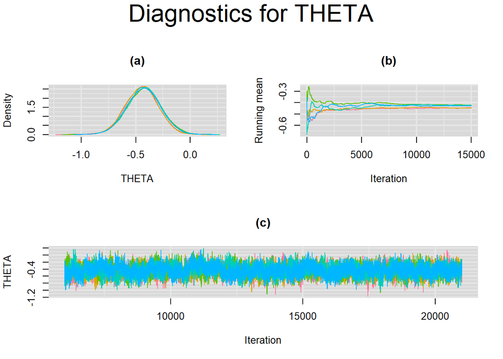

## SUMMARY STATISTICS

Once convergence of the MCMC algorithm is achieved, summary statistics of the parameters of interest may be extracted from their posterior samples using the `MCMCsummary` function found in the `MCMCvis` package.

```r
# Summary statistics
MCMCsummary(output, params=c("THETA", "LAMBDA", "beta","tau.sq"), round=4)
```

Below is the output for the summary statistics of parameters shared across studies. The 50% quantile is the posterior median which is commonly reported as a point estimate of the paramater of interest. Its corresponding 95% credible interval is given by the 2.5% and 97.5% quantiles.

The table also displays `Rhat`, which is the Gelman-Rubin statistic (Gelman and Ruben(1992), Brooks and Gelman(1998)). It is enabled when 2 or more chains are generated. It evaluates MCMC convergence by comparing within- and between-chain variability for each model parameter. `Rhat` tends to 1 as convergence is approached.

`n.eff` is the effective sample size (Gelman et al(2013)). The MCMC process causes the posterior draws to be correlated. The effective sample size is an estimate of the sample size required to achieve the same level of precision with a simple random sample. If draws are highly correlated, the effective sample size will be much lower than the number of posterior samples used to calculate the summary statistics.

```r
# Summary statistics
library(MCMCvis)
MCMCsummary(output, params=c("THETA", "LAMBDA", "beta","tau.sq"), round=4)
```

```
##              mean     sd    2.5%     50%   97.5% Rhat n.eff
## THETA     -0.4333 0.1533 -0.7356 -0.4322 -0.1342 1.00  1603
## LAMBDA     2.6106 0.1917  2.2386  2.6088  2.9938 1.00  5883
## beta       0.2343 0.1637 -0.0823  0.2343  0.5579 1.01   647
## tau.sq[1]  1.3718 0.3205  0.8689  1.3299  2.1153 1.00 24777
## tau.sq[2]  0.6238 0.1397  0.4043  0.6049  0.9484 1.00 31022
```

## SROC PLOT

The output from rjags can be used to create a summary receiver operating characteristic (SROC) curve (black line) using the `SROC_rjags` function found in the `DTAplots` package. Sensitivity and specificity estimates from individual studies are represented by circles with diameter proportional to the study sample size.

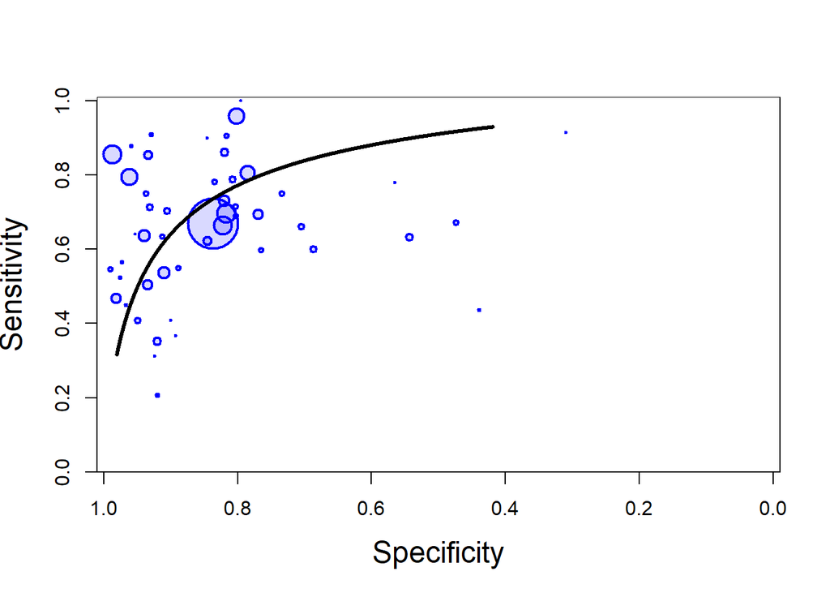

```r
library(DTAplots)
SROC_rjags(X=output, model="HSROC",n=n, study_col1="blue", study_col2=rgb(0, 0, 1, 0.15), dataset=cbind(TP,FP,FN,TN), ref_std=TRUE, Sp.range=c(0,1), SROC_curve = TRUE, cred_region = FALSE, predict_region = FALSE)
```

## SCRIPT

For a copy of the complete script, please follow the link below

[Link to whole script](https://nandinidendukuri.com/documents/Software/R%20script%20rjags%20HSROC%20for%20Website.txt)

## REFERENCES

Brooks, S. P., and A Gelman. 1998. “General methods for monitoring convergence of iterative simulations.” *Journal of Computational and Graphical Statistics*, no. 7: 434–55.

Chu, H., S. Chen, and T. A. Louis. 2009. “Random effects models in a meta-analysis of the accuracy of two diagnostic tests without a gold standard.” *Journal of Clinical Epidemiology*, no. 104(486): 512–23.

Gelman, A, J. B. Carlin, H. S. Stern, D. B. Dunson, A Vehtari, and D. B. Rbin. 2013. “Bayesian Data Analysis.” *Chapman & Hall/CRC Press, London, Third Edition*.

Gelman, A, and D. B. Rubin. 1992. “Inference from iterative simulation using multiple sequences.” *Statistical Sciences*, no. 7: 457–72.

Nishimura, K, D Sugiyama, Y Kogata, G Tsuji, T Nakazawa, S Kawano, K Saigo, et al. 2007. “Meta-analysis: diagnostic accuracy of anti-cyclic citrullinated peptide antibody and rheumatoid factor for rheumatoid arthritis.” *Ann. Intern. Med.*, no. 146(11): 797–808.

Plummer, M. 2003. “JAGS: A Program for Analysis of Bayesian Graphical Models using Gibbs Sampling.” *3rd International Workshop on Distributed Statistical Computing (DSC 2003), Vienna, Austria*, no. 124.

Rutter, C. M., and C. A. Gatsonis. 2001. “A hierarchical regression approach to meta-analysis of diagnostic test accuracy evaluations.” *Statist. Med.*, no. 20: 2868–84. https://doi.org/10.1002/sim.942.

Team, R Core. 2020. “R: A language and environment for statistical computing. R Foundation for Statistical Computing, Vienna, Austria.” https://www.R-project.org/.